# Individual Model Fits (Pilot Data) (Excluding RQ objects)

# Averages from included subjects (n=18)

- Target proportion: mean = .39, SEM = .04
- Target distribution SD: mean = 33.99 deg., SEM = 3.34 deg.
- Mean shift: -5.64 deg., SEM: 3.42 deg. (NO LONGER SIGNIFICANT)
- Rich quadrant proportion: mean = .45, SEM = .05
- Far quadrant proportion: mean = .01s, SEM = .001
- Biased guessing proportion (same SD used for RQ and FQ proportions): mean = 49.91 deg., SEM = 4.75 deg.
- Random guessing proportion: mean = .15, SEM: .04

## Priors:

[figure not shown]

## Exclusions:

- IF TARGET_PROP < .15
- IF (1-TARGET_PROP) * TARGET_SD > 35
- IF (1-RQ_PROP) * BIASED_SD > 45 (given that RQ_PROP > .05)

In other words, exclude if:

- not enough target proportion
- if target standard deviation is too large with respect to the amount of data that's not described by the target proportion
- if biased guessing standard deviation is too large with respect to the amount of data that's not described by the RQ (needs to be at least some data accounted for by the RQ proportion)

## Included Subjects (n=18)

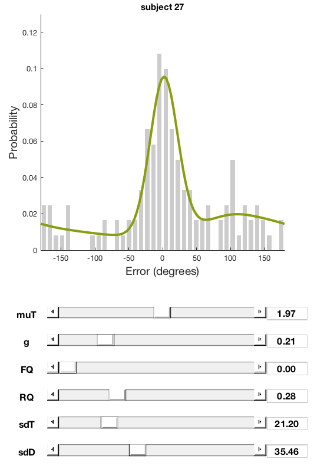

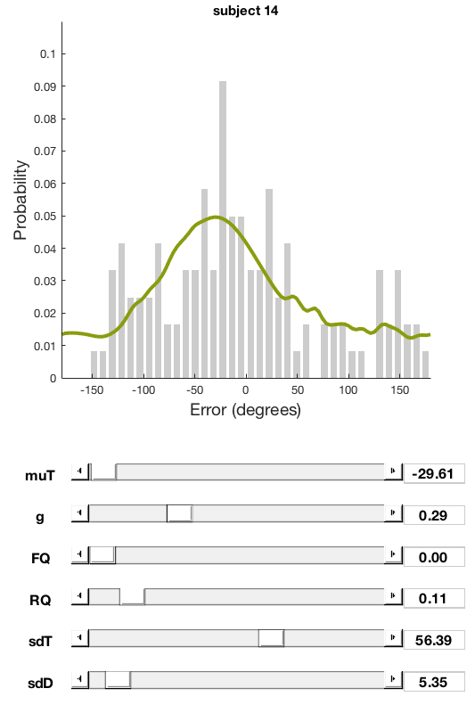

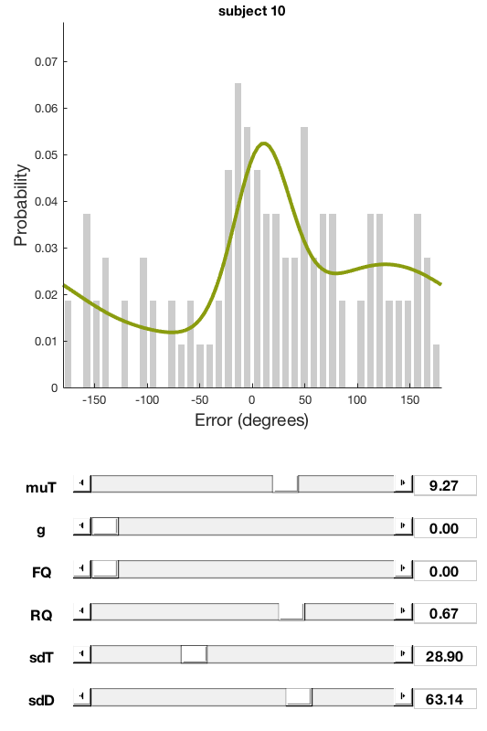

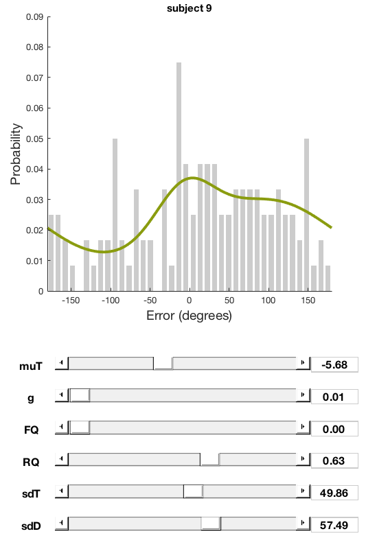

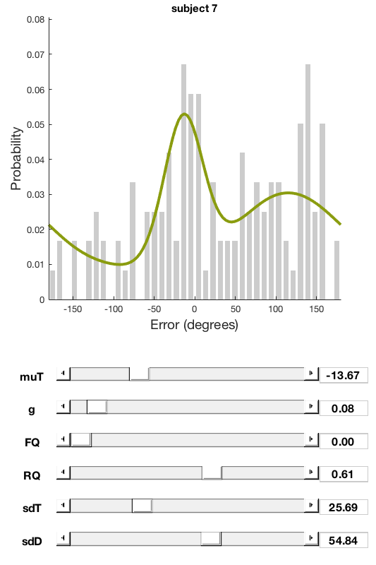

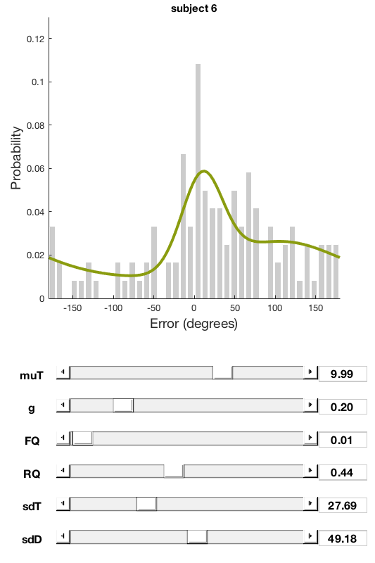

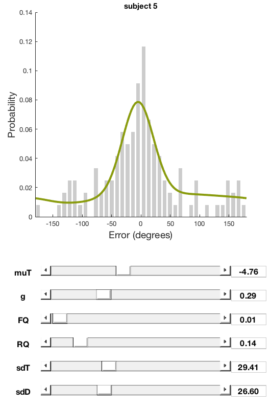

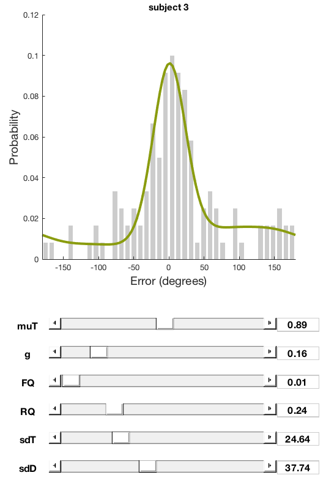

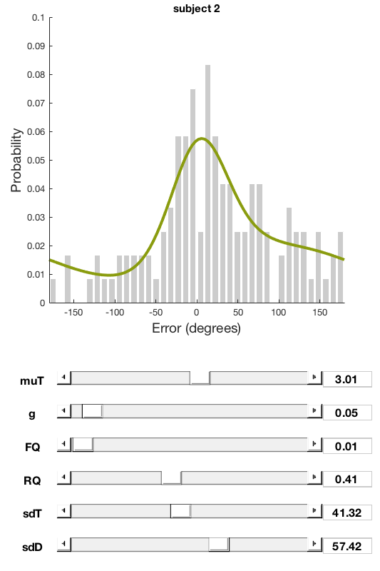

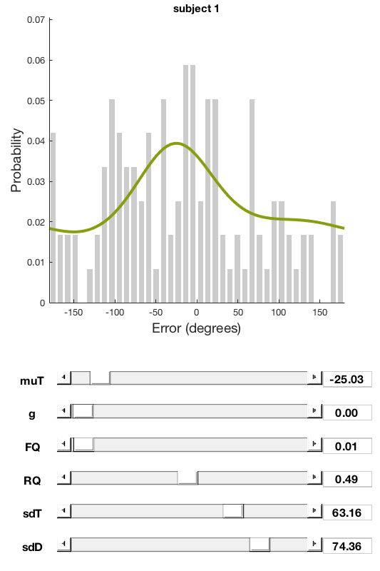

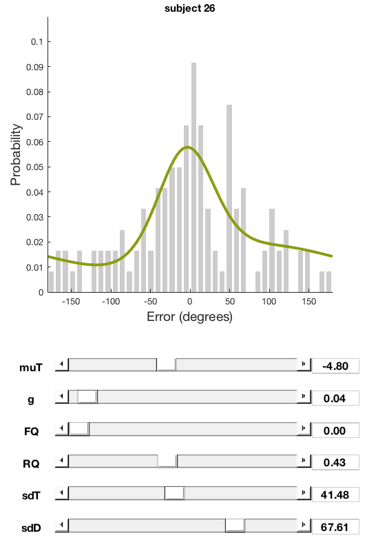

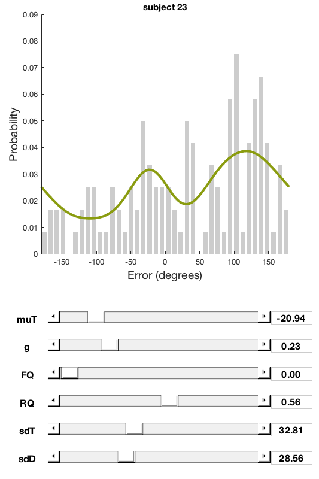

[6 more figures not shown]

```matlab
cd '/Users/scotti.5/Dropbox/Shared Lab Folder/Experiments/Contextual_LTM/Contextual bias in LTM Exp_V9'
openfig('test30_subject1.fig');
openfig('test30_subject2.fig');
openfig('test30_subject3.fig');
openfig('test30_subject5.fig');
openfig('test30_subject6.fig');
openfig('test30_subject7.fig');
openfig('test30_subject9.fig');
openfig('test30_subject10.fig');
openfig('test30_subject14.fig');
openfig('test30_subject15.fig');
openfig('test30_subject16.fig');
openfig('test30_subject18.fig');
openfig('test30_subject20.fig');
openfig('test30_subject21.fig');
openfig('test30_subject22.fig');
openfig('test30_subject23.fig');
openfig('test30_subject26.fig');
openfig('test30_subject27.fig');
```

## Excluded Subjects (n=8)

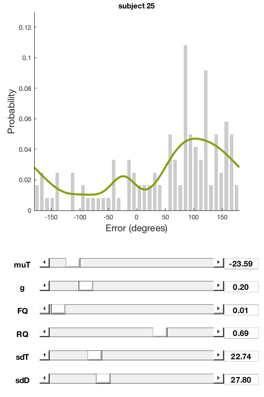

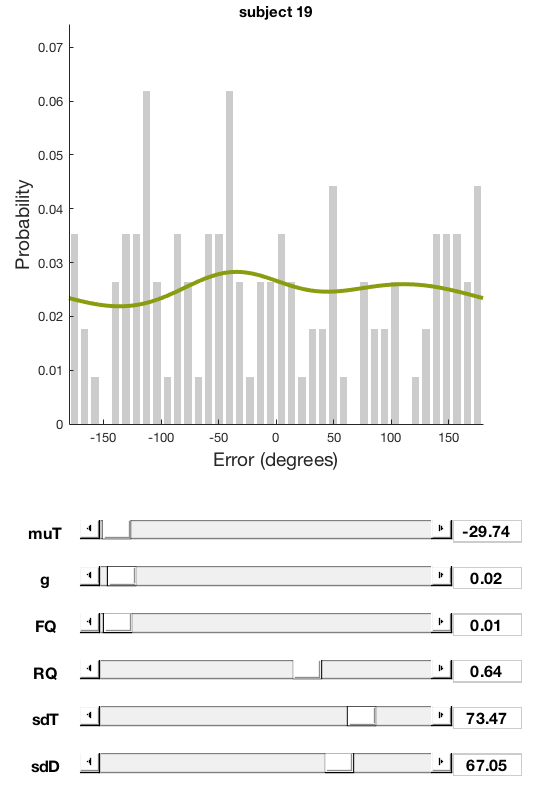

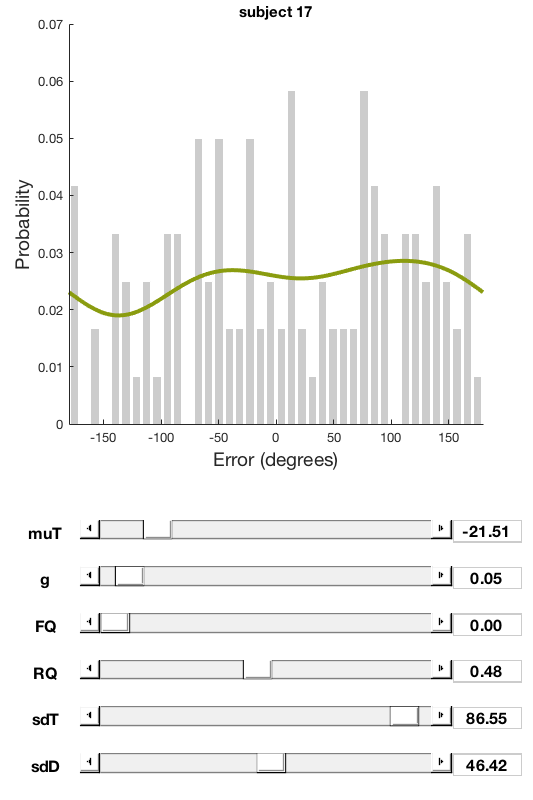

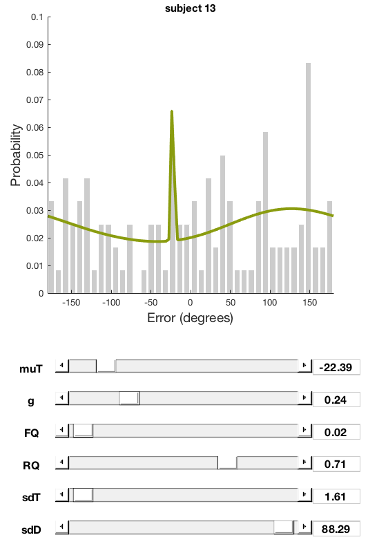

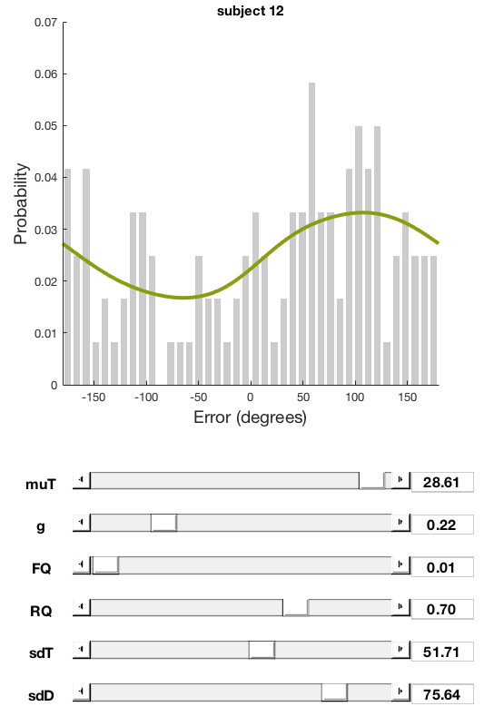

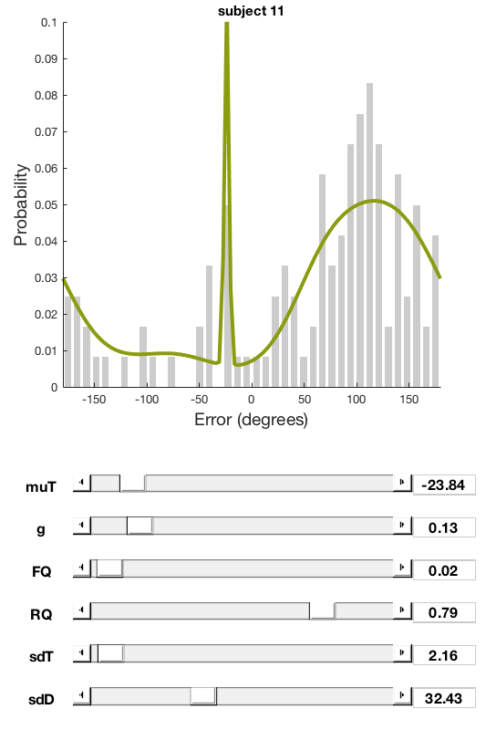

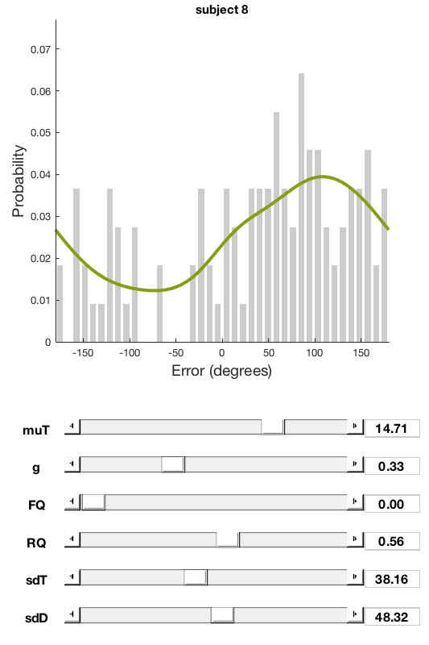

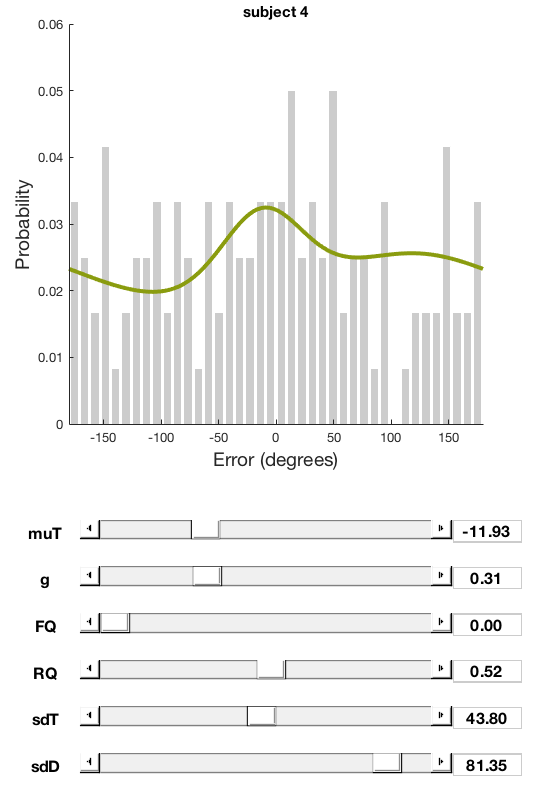

```matlab
cd '/Users/scotti.5/Dropbox/Shared Lab Folder/Experiments/Contextual_LTM/Contextual bias in LTM Exp_V9'
openfig('test30_subject4.fig');
openfig('test30_subject8.fig');
openfig('test30_subject11.fig');
openfig('test30_subject12.fig');
openfig('test30_subject13.fig');
openfig('test30_subject17.fig');
openfig('test30_subject19.fig');
openfig('test30_subject25.fig');
```